# Over view

# In this dataset,we will work with the advertising data of a marketing agency that predicts if a particular user will click on advertisement.

The data consists of 10 variables:

# Daily Time spent on Time

# Daily Internet Usage

# Age

# Area income

# Ad Topic Line

# Male

# Country

# City

# Timestamp

# Clicked on Ad.

The main variable we are interested is Clicked on Ad.This variable can have two possible outcomes:0 & 1 where 0 refers to case where an user didn't clicked on the Ad while 1 refers to the case where user clicks the advertisement. We will see if we can use the other 9 variables to accurately predict the value'Clicked on Ad variable'.

# Importing Libraries

```python
import pandas as pd
import matplotlib.pyplot as plt
import numpy as np
import seaborn as sns
```

# 1.Read the data

```python
#q-1
df= pd.read_csv("advertising_classification.csv")
```

```python
df
```

|  | Daily Time Spent on Site | Age | Area Income | Daily Internet Usage | Ad Topic Line | City | Male | Country | Timestamp | Clicked on Ad |
| --- | --- | --- | --- | --- | --- | --- | --- | --- | --- | --- |
| 0 | 68.95 | 35 | 61833.90 | 256.09 | Cloned 5thgeneration orchestration | Wrightburgh | 0 | Tunisia | 2016-03-27 00:53:11 | 0 |
| 1 | 80.23 | 31 | 68441.85 | 193.77 | Monitored national standardization | West Jodi | 1 | Nauru | 2016-04-04 01:39:02 | 0 |
| 2 | 69.47 | 26 | 59785.94 | 236.50 | Organic bottom-line service-desk | Davidton | 0 | San Marino | 2016-03-13 20:35:42 | 0 |
| 3 | 74.15 | 29 | 54806.18 | 245.89 | Triple-buffered reciprocal time-frame | West Terrifurt | 1 | Italy | 2016-01-10 02:31:19 | 0 |
| 4 | 68.37 | 35 | 73889.99 | 225.58 | Robust logistical utilization | South Manuel | 0 | Iceland | 2016-06-03 03:36:18 | 0 |
| ... | ... | ... | ... | ... | ... | ... | ... | ... | ... | ... |
| 995 | 72.97 | 30 | 71384.57 | 208.58 | Fundamental modular algorithm | Duffystad | 1 | Lebanon | 2016-02-11 21:49:00 | 1 |
| 996 | 51.30 | 45 | 67782.17 | 134.42 | Grass-roots cohesive monitoring | New Darlene | 1 | Bosnia and Herzegovina | 2016-04-22 02:07:01 | 1 |
| 997 | 51.63 | 51 | 42415.72 | 120.37 | Expanded intangible solution | South Jessica | 1 | Mongolia | 2016-02-01 17:24:57 | 1 |
| 998 | 55.55 | 19 | 41920.79 | 187.95 | Proactive bandwidth-monitored policy | West Steven | 0 | Guatemala | 2016-03-24 02:35:54 | 0 |
| 999 | 45.01 | 26 | 29875.80 | 178.35 | Virtual 5thgeneration emulation | Ronniemouth | 0 | Brazil | 2016-06-03 21:43:21 | 1 |

1000 rows × 10 columns

# 2.Print first 20 rows

```python
#q-2
df.head(20)
```

|  | Daily Time Spent on Site | Age | Area Income | Daily Internet Usage | Ad Topic Line | City | Male | Country | Timestamp | Clicked on Ad |
| --- | --- | --- | --- | --- | --- | --- | --- | --- | --- | --- |
| 0 | 68.95 | 35 | 61833.90 | 256.09 | Cloned 5thgeneration orchestration | Wrightburgh | 0 | Tunisia | 2016-03-27 00:53:11 | 0 |
| 1 | 80.23 | 31 | 68441.85 | 193.77 | Monitored national standardization | West Jodi | 1 | Nauru | 2016-04-04 01:39:02 | 0 |
| 2 | 69.47 | 26 | 59785.94 | 236.50 | Organic bottom-line service-desk | Davidton | 0 | San Marino | 2016-03-13 20:35:42 | 0 |
| 3 | 74.15 | 29 | 54806.18 | 245.89 | Triple-buffered reciprocal time-frame | West Terrifurt | 1 | Italy | 2016-01-10 02:31:19 | 0 |
| 4 | 68.37 | 35 | 73889.99 | 225.58 | Robust logistical utilization | South Manuel | 0 | Iceland | 2016-06-03 03:36:18 | 0 |
| 5 | 59.99 | 23 | 59761.56 | 226.74 | Sharable client-driven software | Jamieberg | 1 | Norway | 2016-05-19 14:30:17 | 0 |
| 6 | 88.91 | 33 | 53852.85 | 208.36 | Enhanced dedicated support | Brandonstad | 0 | Myanmar | 2016-01-28 20:59:32 | 0 |
| 7 | 66.00 | 48 | 24593.33 | 131.76 | Reactive local challenge | Port Jefferybury | 1 | Australia | 2016-03-07 01:40:15 | 1 |
| 8 | 74.53 | 30 | 68862.00 | 221.51 | Configurable coherent function | West Colin | 1 | Grenada | 2016-04-18 09:33:42 | 0 |
| 9 | 69.88 | 20 | 55642.32 | 183.82 | Mandatory homogeneous architecture | Ramirezton | 1 | Ghana | 2016-07-11 01:42:51 | 0 |
| 10 | 47.64 | 49 | 45632.51 | 122.02 | Centralized neutral neural-net | West Brandonton | 0 | Qatar | 2016-03-16 20:19:01 | 1 |
| 11 | 83.07 | 37 | 62491.01 | 230.87 | Team-oriented grid-enabled Local Area Network | East Theresashire | 1 | Burundi | 2016-05-08 08:10:10 | 0 |
| 12 | 69.57 | 48 | 51636.92 | 113.12 | Centralized content-based focus group | West Katiefurt | 1 | Egypt | 2016-06-03 01:14:41 | 1 |
| 13 | 79.52 | 24 | 51739.63 | 214.23 | Synergistic fresh-thinking array | North Tara | 0 | Bosnia and Herzegovina | 2016-04-20 21:49:22 | 0 |
| 14 | 42.95 | 33 | 30976.00 | 143.56 | Grass-roots coherent extranet | West William | 0 | Barbados | 2016-03-24 09:31:49 | 1 |
| 15 | 63.45 | 23 | 52182.23 | 140.64 | Persistent demand-driven interface | New Travistown | 1 | Spain | 2016-03-09 03:41:30 | 1 |
| 16 | 55.39 | 37 | 23936.86 | 129.41 | Customizable multi-tasking website | West Dylanberg | 0 | Palestinian Territory | 2016-01-30 19:20:41 | 1 |
| 17 | 82.03 | 41 | 71511.08 | 187.53 | Intuitive dynamic attitude | Pruittmouth | 0 | Afghanistan | 2016-05-02 07:00:58 | 0 |
| 18 | 54.70 | 36 | 31087.54 | 118.39 | Grass-roots solution-oriented conglomeration | Jessicastad | 1 | British Indian Ocean Territory (Chagos Archipe... | 2016-02-13 07:53:55 | 1 |
| 19 | 74.58 | 40 | 23821.72 | 135.51 | Advanced 24/7 productivity | Millertown | 1 | Russian Federation | 2016-02-27 04:43:07 | 1 |

# 3.Find data type of the data

```python
#q-3
df.dtypes
```

```
Daily Time Spent on Site    float64
Age                           int64
Area Income                 float64
Daily Internet Usage        float64
Ad Topic Line                object
City                         object
Male                          int64
Country                      object
Timestamp                    object
Clicked on Ad                 int64
dtype: object
```

# 4.Find Null Values if any

```python
#q-4
df.isnull().sum()
```

```
Daily Time Spent on Site    0
Age                         0
Area Income                 0
Daily Internet Usage        0
Ad Topic Line               0
City                        0
Male                        0
Country                     0
Timestamp                   0
Clicked on Ad               0
dtype: int64
```

```python
# There is no null values in the dataset
```

# 5.Print information and summary

```python
#q-5
df.info()
```

```
<class 'pandas.core.frame.DataFrame'>
RangeIndex: 1000 entries, 0 to 999
Data columns (total 10 columns):
 #   Column                    Non-Null Count  Dtype
---  ------                    --------------  -----
 0   Daily Time Spent on Site  1000 non-null   float64
 1   Age                       1000 non-null   int64
 2   Area Income               1000 non-null   float64
 3   Daily Internet Usage      1000 non-null   float64
 4   Ad Topic Line             1000 non-null   object
 5   City                      1000 non-null   object
 6   Male                      1000 non-null   int64
 7   Country                   1000 non-null   object
 8   Timestamp                 1000 non-null   object
 9   Clicked on Ad             1000 non-null   int64
dtypes: float64(3), int64(3), object(4)
memory usage: 78.2+ KB
```

```python
df.describe()
```

|  | Daily Time Spent on Site | Age | Area Income | Daily Internet Usage | Male | Clicked on Ad |
| --- | --- | --- | --- | --- | --- | --- |
| count | 1000.000000 | 1000.000000 | 1000.000000 | 1000.000000 | 1000.000000 | 1000.00000 |
| mean | 65.000200 | 36.009000 | 55000.000080 | 180.000100 | 0.481000 | 0.50000 |
| std | 15.853615 | 8.785562 | 13414.634022 | 43.902339 | 0.499889 | 0.50025 |
| min | 32.600000 | 19.000000 | 13996.500000 | 104.780000 | 0.000000 | 0.00000 |
| 25% | 51.360000 | 29.000000 | 47031.802500 | 138.830000 | 0.000000 | 0.00000 |
| 50% | 68.215000 | 35.000000 | 57012.300000 | 183.130000 | 0.000000 | 0.50000 |
| 75% | 78.547500 | 42.000000 | 65470.635000 | 218.792500 | 1.000000 | 1.00000 |
| max | 91.430000 | 61.000000 | 79484.800000 | 269.960000 | 1.000000 | 1.00000 |

# 6. Shape and size of the data

```python
#q-6
df.shape
```

```
(1000, 10)
```

```python
df.size
```

```
10000
```

# 7.Print all columns name

```python
df.columns
```

```
Index(['Daily Time Spent on Site', 'Age', 'Area Income',
       'Daily Internet Usage', 'Ad Topic Line', 'City', 'Male', 'Country',
       'Timestamp', 'Clicked on Ad'],
      dtype='object')
```

# 8.How many click on Ad and not clicked on Ad

```python
#q-8 How many click on Ad or not and show in pie chart
b= df["Clicked on Ad"].value_counts()
```

```python
b
```

```
1    500
0    500
Name: Clicked on Ad, dtype: int64
```

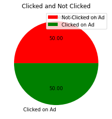

```python
plt.pie(b,colors= ["red","green"],labels=["Not-Clicked on Ad","Clicked on Ad"],autopct = "%0.2f")
plt.title("Clicked and Not Clicked")
plt.legend(loc="upper right")
plt.show()
```

# 9.Find SD of daily Internet usage

```python
#q-9 Find standard deviation of daily internet usage
```

```python
df.iloc[10:20,3:4]
```

|  | Daily Internet Usage |
| --- | --- |
| 10 | 122.02 |
| 11 | 230.87 |
| 12 | 113.12 |
| 13 | 214.23 |
| 14 | 143.56 |
| 15 | 140.64 |
| 16 | 129.41 |
| 17 | 187.53 |
| 18 | 118.39 |
| 19 | 135.51 |

```python
np.std(df["Daily Internet Usage"])
```

```
43.88038264179109
```

# 10.Find Average area wise income

```python
#q-10 Find average area income
```

```python
n = df["Area Income"].count()
```

```python
avg = (df["Area Income"].sum())/n
```

```python
avg
```

```
55000.000080000005
```

# 11.Plot a Histogram showing daily internet usage

```python
# q-11 Histogram showing daily internet Usage
```

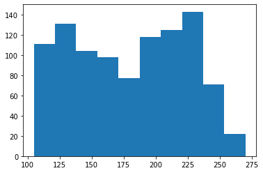

```python
x = df["Daily Internet Usage"]
plt.hist(x,bins =10)
plt.show()
```